# Practicum1_SUN

# Problem 2

1.Investigate this data set of home prices in King County (USA).

```r
homeprice <- read.csv("/Users/sunmengyue/Dropbox/2. Northeastern Unviersity/Fall2018/DA 5030 DataMining and Machine Learning/data analytics/kc_house_data.csv")
str(homeprice)
```

```
## 'data.frame':    21613 obs. of  21 variables:
##  $ id           : num  7.13e+09 6.41e+09 5.63e+09 2.49e+09 1.95e+09 ...
##  $ date         : Factor w/ 372 levels "20140502T000000",..: 165 221 291 221 284 11 57 252 340 306 ...
##  $ price        : num  221900 538000 180000 604000 510000 ...
##  $ bedrooms     : int  3 3 2 4 3 4 3 3 3 3 ...
##  $ bathrooms    : num  1 2.25 1 3 2 4.5 2.25 1.5 1 2.5 ...
##  $ sqft_living  : int  1180 2570 770 1960 1680 5420 1715 1060 1780 1890 ...
##  $ sqft_lot     : int  5650 7242 10000 5000 8080 101930 6819 9711 7470 6560 ...
##  $ floors       : num  1 2 1 1 1 1 2 1 1 2 ...
##  $ waterfront   : int  0 0 0 0 0 0 0 0 0 0 ...
##  $ view         : int  0 0 0 0 0 0 0 0 0 0 ...
##  $ condition    : int  3 3 3 5 3 3 3 3 3 3 ...
##  $ grade        : int  7 7 6 7 8 11 7 7 7 7 ...
##  $ sqft_above   : int  1180 2170 770 1050 1680 3890 1715 1060 1050 1890 ...
##  $ sqft_basement: int  0 400 0 910 0 1530 0 0 730 0 ...
##  $ yr_built     : int  1955 1951 1933 1965 1987 2001 1995 1963 1960 2003 ...
##  $ yr_renovated : int  0 1991 0 0 0 0 0 0 0 0 ...
##  $ zipcode      : int  98178 98125 98028 98136 98074 98053 98003 98198 98146 98038 ...
##  $ lat          : num  47.5 47.7 47.7 47.5 47.6 ...
##  $ long         : num  -122 -122 -122 -122 -122 ...
##  $ sqft_living15: int  1340 1690 2720 1360 1800 4760 2238 1650 1780 2390 ...
##  $ sqft_lot15   : int  5650 7639 8062 5000 7503 101930 6819 9711 8113 7570 ...
```

```r
# We know that there are 21613 cases, 21 features.

#To use knn to predict the home price, I will break down the home price in to several range and transfer the variable to factor
summary(homeprice$price)
```

```
##    Min. 1st Qu.  Median    Mean 3rd Qu.    Max.
##   75000  321950  450000  540088  645000 7700000
```

```r
homePrice2 <- within(homeprice, {
  price[price < 100000] <- "< 100000"
  price[price >= 100000 & price < 600000 ] <- "100000-59999"
  price[price >= 600000 & price < 1100000 ] <- "600000-1099999"
  price[price >= 1100000 & price < 1600000 ] <- "1100000-1599999"
  price[price >= 1600000] <- ">1600000"
})
homePrice2$price <- factor(homePrice2$price,
                           levels = c("< 100000", "100000-59999","600000-1099999", "1100000-1599999", ">1600000"))
str(homePrice2$price)
```

```
##  Factor w/ 5 levels "< 100000","100000-59999",..: 2 2 5 2 2 4 2 2 2 2 ...
```

```r
summary(homePrice2)
```

```
##        id                         date                   price
##  Min.   :1.000e+06   20140623T000000:  142   < 100000       :   25
##  1st Qu.:2.123e+09   20140625T000000:  131   100000-59999   :16541
##  Median :3.905e+09   20140626T000000:  131   600000-1099999 :    0
##  Mean   :4.580e+09   20140708T000000:  127   1100000-1599999: 1009
##  3rd Qu.:7.309e+09   20150427T000000:  126   >1600000       : 3774
##  Max.   :9.900e+09   20150325T000000:  123   NA's           :  264
##                      (Other)        :20833
##     bedrooms        bathrooms      sqft_living       sqft_lot
##  Min.   : 0.000   Min.   :0.000   Min.   :  290   Min.   :    520
##  1st Qu.: 3.000   1st Qu.:1.750   1st Qu.: 1427   1st Qu.:   5040
##  Median : 3.000   Median :2.250   Median : 1910   Median :   7618
##  Mean   : 3.371   Mean   :2.115   Mean   : 2080   Mean   :  15107
##  3rd Qu.: 4.000   3rd Qu.:2.500   3rd Qu.: 2550   3rd Qu.:  10688
##  Max.   :33.000   Max.   :8.000   Max.   :13540   Max.   :1651359
##
##      floors        waterfront            view          condition
##  Min.   :1.000   Min.   :0.000000   Min.   :0.0000   Min.   :1.000
##  1st Qu.:1.000   1st Qu.:0.000000   1st Qu.:0.0000   1st Qu.:3.000
##  Median :1.500   Median :0.000000   Median :0.0000   Median :3.000
##  Mean   :1.494   Mean   :0.007542   Mean   :0.2343   Mean   :3.409
##  3rd Qu.:2.000   3rd Qu.:0.000000   3rd Qu.:0.0000   3rd Qu.:4.000
##  Max.   :3.500   Max.   :1.000000   Max.   :4.0000   Max.   :5.000
##
##      grade          sqft_above   sqft_basement       yr_built
##  Min.   : 1.000   Min.   : 290   Min.   :   0.0   Min.   :1900
##  1st Qu.: 7.000   1st Qu.:1190   1st Qu.:   0.0   1st Qu.:1951
##  Median : 7.000   Median :1560   Median :   0.0   Median :1975
##  Mean   : 7.657   Mean   :1788   Mean   : 291.5   Mean   :1971
##  3rd Qu.: 8.000   3rd Qu.:2210   3rd Qu.: 560.0   3rd Qu.:1997
##  Max.   :13.000   Max.   :9410   Max.   :4820.0   Max.   :2015
##
##   yr_renovated       zipcode           lat             long
##  Min.   :   0.0   Min.   :98001   Min.   :47.16   Min.   :-122.5
##  1st Qu.:   0.0   1st Qu.:98033   1st Qu.:47.47   1st Qu.:-122.3
##  Median :   0.0   Median :98065   Median :47.57   Median :-122.2
##  Mean   :  84.4   Mean   :98078   Mean   :47.56   Mean   :-122.2
##  3rd Qu.:   0.0   3rd Qu.:98118   3rd Qu.:47.68   3rd Qu.:-122.1
##  Max.   :2015.0   Max.   :98199   Max.   :47.78   Max.   :-121.3
##
##  sqft_living15    sqft_lot15
##  Min.   : 399   Min.   :   651
##  1st Qu.:1490   1st Qu.:  5100
##  Median :1840   Median :  7620
##  Mean   :1987   Mean   : 12768
##  3rd Qu.:2360   3rd Qu.: 10083
##  Max.   :6210   Max.   :871200
##
```

```r
anyNA(homePrice2)
```

```
## [1] TRUE
```

```r
homePrice2 <- na.omit(homePrice2)
str(homePrice2)
```

```
## 'data.frame':    21349 obs. of  21 variables:
##  $ id           : num  7.13e+09 6.41e+09 5.63e+09 2.49e+09 1.95e+09 ...
##  $ date         : Factor w/ 372 levels "20140502T000000",..: 165 221 291 221 284 11 57 252 340 306 ...
##  $ price        : Factor w/ 5 levels "< 100000","100000-59999",..: 2 2 5 2 2 4 2 2 2 2 ...
##  $ bedrooms     : int  3 3 2 4 3 4 3 3 3 3 ...
##  $ bathrooms    : num  1 2.25 1 3 2 4.5 2.25 1.5 1 2.5 ...
##  $ sqft_living  : int  1180 2570 770 1960 1680 5420 1715 1060 1780 1890 ...
##  $ sqft_lot     : int  5650 7242 10000 5000 8080 101930 6819 9711 7470 6560 ...
##  $ floors       : num  1 2 1 1 1 1 2 1 1 2 ...
##  $ waterfront   : int  0 0 0 0 0 0 0 0 0 0 ...
##  $ view         : int  0 0 0 0 0 0 0 0 0 0 ...
##  $ condition    : int  3 3 3 5 3 3 3 3 3 3 ...
##  $ grade        : int  7 7 6 7 8 11 7 7 7 7 ...
##  $ sqft_above   : int  1180 2170 770 1050 1680 3890 1715 1060 1050 1890 ...
##  $ sqft_basement: int  0 400 0 910 0 1530 0 0 730 0 ...
##  $ yr_built     : int  1955 1951 1933 1965 1987 2001 1995 1963 1960 2003 ...
##  $ yr_renovated : int  0 1991 0 0 0 0 0 0 0 0 ...
##  $ zipcode      : int  98178 98125 98028 98136 98074 98053 98003 98198 98146 98038 ...
##  $ lat          : num  47.5 47.7 47.7 47.5 47.6 ...
##  $ long         : num  -122 -122 -122 -122 -122 ...
##  $ sqft_living15: int  1340 1690 2720 1360 1800 4760 2238 1650 1780 2390 ...
##  $ sqft_lot15   : int  5650 7639 8062 5000 7503 101930 6819 9711 8113 7570 ...
##  - attr(*, "na.action")=Class 'omit'  Named int [1:264] 71 92 104 186 219 236 447 461 487 513 ...
##   .. ..- attr(*, "names")= chr [1:264] "71" "92" "104" "186" ...
```

```r
#normalize the dataset
homePriceSub <- as.data.frame(lapply(homePrice2[, c(4 : 21)], normalize))
homePrice3 <- data.frame(cbind(homePrice2[, 2:3]), homePriceSub) #exclude the id column
str(homePrice3)
```

```
## 'data.frame':    21349 obs. of  20 variables:
##  $ date         : Factor w/ 372 levels "20140502T000000",..: 165 221 291 221 284 11 57 252 340 306 ...
##  $ price        : Factor w/ 5 levels "< 100000","100000-59999",..: 2 2 5 2 2 4 2 2 2 2 ...
##  $ bedrooms     : num  0.0909 0.0909 0.0606 0.1212 0.0909 ...
##  $ bathrooms    : num  0.125 0.281 0.125 0.375 0.25 ...
##  $ sqft_living  : num  0.0672 0.1721 0.0362 0.126 0.1049 ...
##  $ sqft_lot     : num  0.00311 0.00407 0.00574 0.00271 0.00458 ...
##  $ floors       : num  0 0.4 0 0 0 0 0.4 0 0 0.4 ...
##  $ waterfront   : num  0 0 0 0 0 0 0 0 0 0 ...
##  $ view         : num  0 0 0 0 0 0 0 0 0 0 ...
##  $ condition    : num  0.5 0.5 0.5 1 0.5 0.5 0.5 0.5 0.5 0.5 ...
##  $ grade        : num  0.5 0.5 0.417 0.5 0.583 ...
##  $ sqft_above   : num  0.0976 0.2061 0.0526 0.0833 0.1524 ...
##  $ sqft_basement: num  0 0.083 0 0.189 0 ...
##  $ yr_built     : num  0.478 0.443 0.287 0.565 0.757 ...
##  $ yr_renovated : num  0 0.988 0 0 0 ...
##  $ zipcode      : num  0.894 0.626 0.136 0.682 0.369 ...
##  $ lat          : num  0.571 0.909 0.936 0.587 0.741 ...
##  $ long         : num  0.218 0.166 0.238 0.105 0.394 ...
##  $ sqft_living15: num  0.162 0.222 0.399 0.165 0.241 ...
##  $ sqft_lot15   : num  0.00574 0.00803 0.00851 0.005 0.00787 ...
```

```r
#data partition
set.seed(9850)
gp <- runif(nrow(homePrice3))
homePrice3 <- homePrice3[order(gp), ]
head(homePrice3, 15)
```

```
##                  date        price   bedrooms bathrooms sqft_living
## 13151 20140520T000000 100000-59999 0.12121212   0.31250  0.12830189
## 18164 20140702T000000 100000-59999 0.15151515   0.31250  0.20075472
## 12776 20150318T000000     >1600000 0.09090909   0.12500  0.03773585
## 18700 20140724T000000 100000-59999 0.15151515   0.34375  0.13358491
## 21516 20141215T000000     >1600000 0.12121212   0.31250  0.24754717
## 14567 20150428T000000 100000-59999 0.06060606   0.12500  0.04226415
## 16027 20141022T000000 100000-59999 0.15151515   0.21875  0.15018868
## 19307 20140523T000000 100000-59999 0.09090909   0.12500  0.09132075
## 221   20140822T000000 100000-59999 0.12121212   0.31250  0.18641509
## 4820  20140822T000000 100000-59999 0.09090909   0.18750  0.07169811
## 17148 20140522T000000     >1600000 0.12121212   0.34375  0.16000000
## 6644  20140621T000000 100000-59999 0.12121212   0.28125  0.15396226
## 11254 20140611T000000     >1600000 0.09090909   0.43750  0.31773585
## 2717  20150424T000000 100000-59999 0.09090909   0.21875  0.08226415
```

[output cut: 49 more lines]

```r
str(homePrice3)
```

```
## 'data.frame':    21349 obs. of  20 variables:
##  $ date         : Factor w/ 372 levels "20140502T000000",..: 19 62 312 84 227 353 174 22 113 113 ...
##  $ price        : Factor w/ 5 levels "< 100000","100000-59999",..: 2 2 5 2 5 2 2 2 2 2 ...
##  $ bedrooms     : num  0.1212 0.1515 0.0909 0.1515 0.1212 ...
##  $ bathrooms    : num  0.312 0.312 0.125 0.344 0.312 ...
##  $ sqft_living  : num  0.1283 0.2008 0.0377 0.1336 0.2475 ...
##  $ sqft_lot     : num  0.00373 0.00302 0.00377 0.00508 0.00345 ...
##  $ floors       : num  0.4 0.2 0 0 0.4 0 0 0 0.4 0 ...
##  $ waterfront   : num  0 0 0 0 0 0 0 0 0 0 ...
##  $ view         : num  0 0 0 0 0 0 0.25 0 0 0 ...
##  $ condition    : num  0.5 1 0.25 0.75 0.5 0.75 0.75 0.5 0.5 0.5 ...
##  $ grade        : num  0.5 0.5 0.417 0.5 0.667 ...
##  $ sqft_above   : num  0.1864 0.1568 0.0548 0.102 0.3596 ...
##  $ sqft_basement: num  0 0.255 0 0.174 0 ...
##  $ yr_built     : num  0.774 0.157 0.383 0.678 0.991 ...
##  $ yr_renovated : num  0 0 0 0 0 0 0 0 0 0 ...
##  $ zipcode      : num  0.111 0.722 0.894 0.591 0.258 ...
##  $ lat          : num  0.244 0.68 0.551 0.611 0.883 ...
##  $ long         : num  0.134 0.188 0.232 0.191 0.329 ...
##  $ sqft_living15: num  0.2518 0.3099 0.0965 0.248 0.4872 ...
##  $ sqft_lot15   : num  0.00679 0.005 0.00649 0.00948 0.00611 ...
```

```r
nrow(homePrice3)
```

```
## [1] 21349
```

```r
priceTrain <- homePrice3[1 : 14944, ] #70% of the data are set as training
priceTest <- homePrice3[14945 : 21349, ]
priceTrainTarget <- priceTrain$price
priceTestTarget <- priceTest$price

sqrt(nrow(homePrice3))
```

```
## [1] 146.113
```

```r
predTest <- knn(train = priceTrain[3:20], test = priceTest[3:20], cl = priceTrainTarget, k = 147)
table(priceTestTarget, predTest)
```

```
##                  predTest
## priceTestTarget   < 100000 100000-59999 600000-1099999 1100000-1599999
##   < 100000               0           10              0               0
##   100000-59999           0         4784              0               4
##   600000-1099999         0            0              0               0
##   1100000-1599999        0          139              0               0
##   >1600000               0          779              0               0
##                  predTest
## priceTestTarget   >1600000
##   < 100000               0
##   100000-59999         105
##   600000-1099999         0
##   1100000-1599999      153
##   >1600000             431
```

2. How would you evaluate the model? While you need to only describe how to evaluate the model, you may calculate an actual metric.

```r
nrow(predTest)
```

[output not shown]

```r
AccuracyRate <-  (4784 + 431) / 6405
AccuracyRate
```

```
## [1] 0.8142077
```

```r
#The model has a good accuracy rate at 81.42%
```

# Problem 3

13. Inspect the data set of occupancy rates for a series of time periods. Which forecasting method is most appropriate to use for forecast the next time period? Calculate a forecast for the next time period with a 95% prediction interval. Comment on the bias of your forecasting model

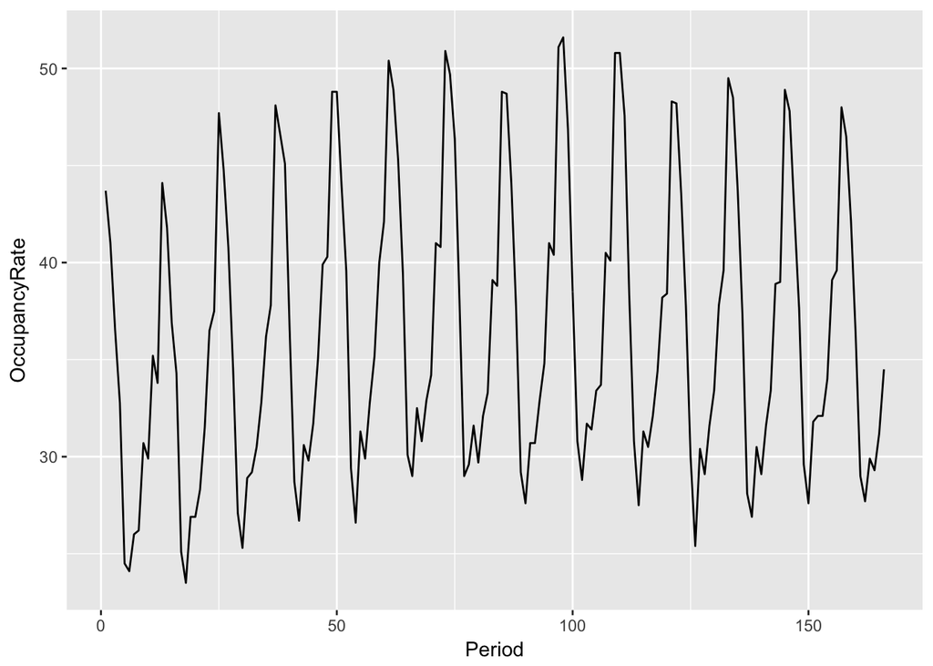

```r
Occupancy <- read.csv("/Users/sunmengyue/Dropbox/2. Northeastern Unviersity/Fall2018/DA 5030 DataMining and Machine Learning/week4/practicum/occupancyratestimeseries (1).csv")

ggplot(Occupancy, aes(x = Period, y = OccupancyRate)) + geom_line()
```

```r
# Because ther change is drastic, weighted moving average is not a good fit. We can see there is a general patter in the graph. So we will try exponential smoothing and linear regression which use all of the data point to predic the occupancy rate at the next time period.
#Exponential Smoothing
#alpha = 0.3
Occupancy$Ft = 0
Occupancy$E = 0
head(Occupancy)
```

```
##   Period OccupancyRate Ft E
## 1      1          43.7  0 0
## 2      2          41.0  0 0
## 3      3          36.5  0 0
## 4      4          32.8  0 0
## 5      5          24.5  0 0
## 6      6          24.1  0 0
```

```r
Occupancy$Ft[1] <- Occupancy[1, 2]
head(Occupancy)
```

```
##   Period OccupancyRate   Ft E
## 1      1          43.7 43.7 0
## 2      2          41.0  0.0 0
## 3      3          36.5  0.0 0
## 4      4          32.8  0.0 0
## 5      5          24.5  0.0 0
## 6      6          24.1  0.0 0
```

```r
#Ft = F(t - 1) + a * E(t - 1)
for (i in 2:nrow(Occupancy)) {
  Occupancy$Ft[i] <- Occupancy$Ft[i - 1] + 0.3 * Occupancy$E[i - 1]
  Occupancy$E[i] <- Occupancy[i, 2] - Occupancy$Ft[i]
}

n <- nrow(Occupancy)
Forcast <- Occupancy$Ft[n] + 0.3 * Occupancy$E[n]
Forcast
```

```
## [1] 32.47969
```

```r
#linear regression
nrow(Occupancy)
```

```
## [1] 166
```

```r
model <- lm(Occupancy$OccupancyRate ~ Occupancy$Period)
summary(model)
```

```
##
## Call:
## lm(formula = Occupancy$OccupancyRate ~ Occupancy$Period)
##
## Residuals:
##     Min      1Q  Median      3Q     Max
## -11.714  -5.877  -1.442   4.836  15.179
##
## Coefficients:
##                  Estimate Std. Error t value Pr(>|t|)
## (Intercept)      34.94191    1.14667  30.473   <2e-16 ***
## Occupancy$Period  0.01510    0.01191   1.267    0.207
## ---
## Signif. codes:  0 '***' 0.001 '**' 0.01 '*' 0.05 '.' 0.1 ' ' 1
##
## Residual standard error: 7.354 on 164 degrees of freedom
## Multiple R-squared:  0.0097, Adjusted R-squared:  0.003662
## F-statistic: 1.606 on 1 and 164 DF,  p-value: 0.2068
```

```r
F167 <- 34.94191 + 0.01510  * 167
F167
```

```
## [1] 37.46361
```

```r
#MSE for Exponential Smoothing
library(tidyverse)
Occupancy <- mutate(Occupancy, sqErr = ( OccupancyRate - Forcast)^2)
ES_MSE <- mean(Occupancy$sqErr)
ES_MSE
```

```
## [1] 67.80477
```

```r
#MSE for linear regression
Occupancy2 <- mutate(Occupancy, sqErr = ( OccupancyRate - F167)^2)
lr_MSE <- mean(Occupancy2$sqErr)
lr_MSE
```

```
## [1] 55.53677
```

```r
#Because the linear regression method has a smaller mean squared error, the linear regression is better.
# 95% confidence interval is yt±1.96σ
mySD <- sd(Occupancy$OccupancyRate)
mySD
```

```
## [1] 7.367027
```

```r
#next time period with a 95% prediction interval
OccupanyRatext1 <- F167 + 1.96 * mySD
OccupanyRateNext2 <- F167 - 1.96 * mySD
OccupanyRatext1
```

```
## [1] 51.90298
```

```r
OccupanyRateNext2
```

```
## [1] 23.02424
```

```r
# The next time period with a 95% prediction interval is 23.02 to 51.90
```